# Difference-in-Differences with a Continuous Treatment

Brantly Callaway

brantly.callaway@uga.edu

University of Georgia

Andrew Goodman-Bacon

andrew@goodman-bacon.com

Federal Reserve Bank of Minneapolis

Pedro Sant’Anna

pedro.santanna@emory.edu

Emory University

November 2, 2023

## What’s Been Happening in the DID Literature?

$\newcommand{\E}{\mathbb{E}} \newcommand{\E}{\mathbb{E}} \newcommand{\var}{\mathrm{var}} \newcommand{\cov}{\mathrm{cov}} \newcommand{\Var}{\mathrm{var}} \newcommand{\Cov}{\mathrm{cov}} \newcommand{\Corr}{\mathrm{corr}} \newcommand{\corr}{\mathrm{corr}} \newcommand{\L}{\mathrm{L}} \renewcommand{\P}{\mathrm{P}} \newcommand{\independent}{{\perp\!\!\!\perp}} \newcommand{\indicator}[1]{ \mathbf{1}\{#1\} }$Economists have long used two-way fixed effects (TWFE) regressions to implement DID identification strategies:
$$\begin{align*}
Y_{it} = \theta_t + \eta_i + \beta^{twfe} D_{it} + e_{it}
\end{align*}$$

A number of papers have diagnosed issues TWFE regressions in this context (de Chaisemartin and D’Haultfœuille 2020; Goodman-Bacon 2021; Sun and Abraham 2021; Borusyak, Jaravel, and Spiess 2022, among others)

Summary of Issues:

- Issues arise due to treatment effect heterogeneity
- $\beta^{twfe}$ from the TWFE regression turns out to be equal to a weighted average of underlying treatment effect parameters (group-time average treatment effects)
- Weights on underlying parameters are (non-transparently) driven by estimation method and can have undesirable properties

## What’s been happening in the DID Literature?

There have also been a number of papers fixing these issues (previous papers plus Callaway and Sant’Anna 2021; Gardner 2022; Wooldridge 2021; Dube et al. 2023)

Intuition:

- In a first step, directly target group-time average treatment effects
- Choose weights on group-time average treatment effects to target parameters of interest (overall $ATT$, event study, or others)

## This Paper

These papers have (largely) focused on the case with a binary, staggered treatment

Current paper: Move from a setting with a binary treatment case to one with a continuous treatment (“dose”)

Some of the arguments involve extending ideas from the binary, staggered treatment case to a setting with continuous treatment

- But we will also face new conceptual issues in this case that do not show up in a setting with a binary treatment

Example:

- Effect of $\underbrace{\textrm{length of school closures}}_{\textrm{continuous treatment}}$ (during Covid) on $\underbrace{\textrm{students' test scores}}_{\textrm{outcome}}$

## This paper

For today, mostly emphasize a continuous treatment, but our results also apply to other settings (with trivial modifications):

- multi-valued treatments (e.g., effect of state-level minimum wage policies on employment)
- binary treatment with differential “exposure” to the treatment (application in the paper: a binary Medicare policy where different hospitals had more exposure to the treatment)

But results do not apply to “fuzzy” DID setups

- Fuzzy DID refers to a setting where a researcher is ultimately interested in understanding the effect of a binary treatment but observes aggregate data (e.g., interested in learning about union wage-premium (at individual level) using state-level data and exploiting variation in the “amount” of unionization across different locations)

## Today’s Talk

1. Identification: What’s the same as in the binary treatment case?
2. Identification: What’s different from the binary treatment case?
3. Interpreting TWFE Regressions
4. Empirical Application

# 1. Identification: What’s the same as in the binary treatment case?

## Continuous Treatment Notation

Potential outcomes notation

- Two time periods: $t^*$ and $t^*-1$
  - No one treated until period $t^*$
  - Some units remain untreated in period $t^*$
- Potential outcomes: $Y_{it^*}(d)$
- Observed outcomes: $Y_{it^*}$ and $Y_{it^*-1}$

  $$Y_{it^*}=Y_{it^*}(D_i) \quad \textrm{and} \quad Y_{it^*-1}=Y_{it^*-1}(0)$$

## Parameters of Interest (ATT-type)

Level Effects (Average Treatment Effect on the Treated)

$$ATT(d|d) := \E[Y_{t^*}(d) - Y_{t^*}(0) | D=d]$$

- Interpretation: The average effect of dose $d$ relative to not being treated *local to the group that actually experienced dose $d$*
- This is the natural analogue of $ATT$ in the binary treatment case

## Parameters of Interest (ATT-type)

Slope Effects (Average Causal Response on the Treated)

$$ACRT(d|d) := \frac{\partial ATT(l|d)}{\partial l} \Big|_{l=d}$$

- Interpretation: $ACRT(d|d)$ is the causal effect of a marginal increase in dose *local to units that actually experienced dose $d$*

We can view $ACRT(d|d)$ as the “building block” here. An aggregated version of it (into a single number) is
$$\begin{align*}
ACRT^O := \E[ACRT(D|D)|D>0]
\end{align*}$$

- $ACRT^O$ averages $ACRT(d|d)$ over the population distribution of the dose
- Like $ATT^O$ for staggered treatment adoption, $ACRT^O$ is the natural target parameter for the TWFE regression in this case

## Identification

**“Standard” Parallel Trends Assumption**

For all $d$,

$$\E[\Delta Y_{t^*}(0) | D=d] = \E[\Delta Y_{t^*}(0) | D=0]$$

## Identification

**“Standard” Parallel Trends Assumption**

For all $d$,

$$\E[\Delta Y_{t^*}(0) | D=d] = \E[\Delta Y_{t^*}(0) | D=0]$$

Then,

$$\begin{aligned}
ATT(d|d) &= \E[Y_{t^*}(d) - Y_{t^*}(0) | D=d] \hspace{150pt}
\end{aligned}$$

## Identification

**“Standard” Parallel Trends Assumption**

For all $d$,

$$\E[\Delta Y_{t^*}(0) | D=d] = \E[\Delta Y_{t^*}(0) | D=0]$$

Then,

$$\begin{aligned}
ATT(d|d) &= \E[Y_{t^*}(d) - Y_{t^*}(0) | D=d] \hspace{150pt}\\
&= \E[Y_{t^*}(d) - Y_{t^*-1}(0) | D=d] - \E[Y_{t^*}(0) - Y_{t^*-1}(0) | D=d]
\end{aligned}$$

## Identification

**“Standard” Parallel Trends Assumption**

For all $d$,

$$\E[\Delta Y_{t^*}(0) | D=d] = \E[\Delta Y_{t^*}(0) | D=0]$$

Then,

$$\begin{aligned}
ATT(d|d) &= \E[Y_{t^*}(d) - Y_{t^*}(0) | D=d] \hspace{150pt}\\
&= \E[Y_{t^*}(d) - Y_{t^*-1}(0) | D=d] - \E[Y_{t^*}(0) - Y_{t^*-1}(0) | D=d]\\
&= \E[Y_{t^*}(d) - Y_{t^*-1}(0) | D=d] - \E[\Delta Y_{t^*}(0) | D=0]
\end{aligned}$$

## Identification

**“Standard” Parallel Trends Assumption**

For all $d$,

$$\E[\Delta Y_{t^*}(0) | D=d] = \E[\Delta Y_{t^*}(0) | D=0]$$

Then,

$$\begin{aligned}
ATT(d|d) &= \E[Y_{t^*}(d) - Y_{t^*}(0) | D=d] \hspace{150pt}\\
&= \E[Y_{t^*}(d) - Y_{t^*-1}(0) | D=d] - \E[Y_{t^*}(0) - Y_{t^*-1}(0) | D=d]\\
&= \E[Y_{t^*}(d) - Y_{t^*-1}(0) | D=d] - \E[\Delta Y_{t^*}(0) | D=0]\\
&= \E[\Delta Y_{t^*} | D=d] - \E[\Delta Y_{t^*} | D=0]
\end{aligned}$$

This is exactly what you would expect

# 2. Identification: What’s different from the binary treatment case?

## Are we done?

Unfortunately, no

Most empirical work with a continuous treatment wants to think about how causal responses vary across dose

- Plot treatment effects as a function of dose and ask: does more dose tends to increase/decrease/not affect outcomes?
- Average causal response parameters *inherently* involve comparisons across slightly different doses

There are new issues related to comparing $ATT(d|d)$ at different doses and interpreting these differences as causal effects

- Unlike the staggered, binary treatment case: No easy fixes here!

## Interpretation Issues

Consider comparing $ATT(d|d)$ for two different doses

$$\begin{aligned}
& ATT(d_h|d_h) - ATT(d_l|d_l) \hspace{350pt}
\end{aligned}$$

## Interpretation Issues

Consider comparing $ATT(d|d)$ for two different doses

$$\begin{aligned}
& ATT(d_h|d_h) - ATT(d_l|d_l) \hspace{350pt}\\
& \hspace{25pt} = \E[Y_{t^*}(d_h)-Y_{t^*}(d_l) | D=d_h] + \E[Y_{t^*}(d_l) - Y_{t^*}(0) | D=d_h] - \E[Y_{t^*}(d_l) - Y_{t^*}(0) | D=d_l]
\end{aligned}$$

## Interpretation Issues

Consider comparing $ATT(d|d)$ for two different doses

$$\begin{aligned}
& ATT(d_h|d_h) - ATT(d_l|d_l) \hspace{350pt}\\
& \hspace{25pt} = \E[Y_{t^*}(d_h)-Y_{t^*}(d_l) | D=d_h] + \E[Y_{t^*}(d_l) - Y_{t^*}(0) | D=d_h] - \E[Y_{t^*}(d_l) - Y_{t^*}(0) | D=d_l]\\
& \hspace{25pt} = \underbrace{\E[Y_{t^*}(d_h) - Y_{t^*}(d_l) | D=d_h]}_{\textrm{Causal Response}} + \underbrace{ATT(d_l|d_h) - ATT(d_l|d_l)}_{\textrm{Selection Bias}}
\end{aligned}$$

“Standard” Parallel Trends is not strong enough to rule out the selection bias terms here

- Implication: If you want to interpret differences in treatment effects across different doses, then you will need stronger assumptions than standard parallel trends
- This problem spills over into identifying $ACRT(d|d)$

## Interpretation Issues

Intuition:

- Difference-in-differences identification strategies result in $ATT(d|d)$ parameters. These are local parameters and difficult to compare to each
- This explanation is similar to thinking about LATEs with two different instruments
- Thus, comparing $ATT(d|d)$ across different values is tricky and not for free

What can you do?

- One idea, just recover $ATT(d|d)$ and interpret it cautiously (interpret it by itself not relative to different values of $d$)
- If you want to compare them to each other, it will come with the cost of additional (structural) assumptions

## Introduce Stronger Assumptions

**“Strong” Parallel Trends Assumption**

For all doses `d` and `l`,

$$\mathbb{E}[Y_{t^*}(d) - Y_{t^*-1}(0) | D=l] = \mathbb{E}[Y_{t^*}(d) - Y_{t^*-1}(0) | D=d]$$

- This is notably different from “Standard” Parallel Trends
- It involves potential outcomes for all values of the dose (not just untreated potential outcomes)
- All dose groups would have experienced the same path of outcomes had they been assigned the same dose

## Introduce Stronger Assumptions

Strong parallel trends is equivalent to a version of treatment effect homogeneity. Notice:

$$\begin{aligned}
ATT(d|d) &= \E[Y_{t^*}(d) - Y_{t^*}(0) | D=d] \hspace{200pt} \
\end{aligned}$$

## Introduce Stronger Assumptions

Strong parallel trends is equivalent to a version of treatment effect homogeneity. Notice:

$$\begin{aligned}
ATT(d|d) &= \E[Y_{t^*}(d) - Y_{t^*}(0) | D=d] \hspace{200pt} \\\
&= \E[Y_{t^*}(d) - Y_{t^*-1}(0) | D=d] - \E[Y_{t^*}(0) - Y_{t^*-1}(0) | D=d] \
\end{aligned}$$

## Introduce Stronger Assumptions

Strong parallel trends is equivalent to a version of treatment effect homogeneity. Notice:

$$\begin{aligned}
ATT(d|d) &= \E[Y_{t^*}(d) - Y_{t^*}(0) | D=d] \hspace{200pt} \\\
&= \E[Y_{t^*}(d) - Y_{t^*-1}(0) | D=d] - \E[Y_{t^*}(0) - Y_{t^*-1}(0) | D=d] \\\
&= \E[Y_{t^*}(d) - Y_{t^*-1}(0) | D=l] - \E[Y_{t^*}(0) - Y_{t^*-1}(0) | D=l] \
\end{aligned}$$

## Introduce Stronger Assumptions

Strong parallel trends is equivalent to a version of treatment effect homogeneity. Notice:

$$\begin{aligned}
ATT(d|d) &= \E[Y_{t^*}(d) - Y_{t^*}(0) | D=d] \hspace{200pt} \\\
&= \E[Y_{t^*}(d) - Y_{t^*-1}(0) | D=d] - \E[Y_{t^*}(0) - Y_{t^*-1}(0) | D=d] \\\
&= \E[Y_{t^*}(d) - Y_{t^*-1}(0) | D=l] - \E[Y_{t^*}(0) - Y_{t^*-1}(0) | D=l] \\\
&= \E[Y_{t^*}(d) - Y_{t^*}(0) | D=l] = ATT(d|l)
\end{aligned}$$

Since this holds for all $d$ and $l$, it also implies that $ATT(d|d) = ATE(d) = \E[Y_{t^*}(d) - Y_{t^*}(0)]$. Thus, under strong parallel trends, we have that

$$ATE(d) = \E[\Delta Y_{t^*}|D=d] - \E[\Delta Y_{t^*}|D=0]$$

RHS is exactly the same expression as for $ATT(d|d)$ under “standard” parallel trends, but here

- assumptions are different
- parameter interpretation is different

## Comparisons across dose

ATE-type parameters do not suffer from the same issues as ATT-type parameters when making comparisons across dose

$$\begin{aligned}
ATE(d_h) - ATE(d_l) &= \E[Y_{t^*}(d_h) - Y_{t^*}(0)] - \E[Y_{t^*}(d_l) - Y_{t^*}(0)]
\end{aligned}$$

## Comparisons across dose

ATE-type parameters do not suffer from the same issues as ATT-type parameters when making comparisons across dose

$$\begin{aligned}
ATE(d_h) - ATE(d_l) &= \E[Y_{t^*}(d_h) - Y_{t^*}(0)] - \E[Y_{t^*}(d_l) - Y_{t^*}(0)]\\
&= \underbrace{\E[Y_{t^*}(d_h) - Y_{t^*}(d_l)]}_{\textrm{Causal Response}}
\end{aligned}$$

Thus, recovering $ATE(d)$ side-steps the issues about comparing treatment effects across doses, but it comes at the cost of needing a (potentially very strong) extra assumption

Given that we can compare $ATE(d)$’s across dose, we can recover slope effects in this setting

$$\begin{aligned}
ACR(d) := \frac{\partial ATE(d)}{\partial d} \qquad &\textrm{or} \qquad ACR^O := \E[ACR(D) | D>0]
\end{aligned}$$

## Additional Comments

- Can you relax strong parallel trends?
- Positive side-comment: No untreated units
- Positive side-comment: Binarizing the Treatment
- Negative side-comment: Pre-testing

## Summarizing

It is straightforward/familiar to identify ATT-type parameters with a multi-valued or continuous dose

However, comparison of ATT-type parameters across different doses are hard to interpret

- They include selection bias terms
- This issues extends to identifying ACRT parameters
- These issues extend to TWFE regressions

This suggests targeting ATE-type parameters

- Comparisons across doses do not contain selection bias terms
- But identifying ATE-type parameters requires stronger assumptions

# 3. Interpreting TWFE Regressions

## TWFE Regressions in this Context

Consider the same TWFE regression (but now $D_{it}$ is continuous):
$$\begin{align*}
Y_{it} = \theta_t + \eta_i + \beta^{TWFE} D_{it} + e_{it}
\end{align*}$$
You can show that
$$\begin{align*}
\beta^{TWFE} = \int_{\mathcal{D}_+} w(l) m'_\Delta(l) \, dl
\end{align*}$$
where $m_\Delta(l) := \E[\Delta Y_{t^*}|D=l] - \E[\Delta Y_{t^*}|D=0]$ and $w(l)$ are weights

- Under standard parallel trends, $m'_{\Delta}(l) = ACRT(l|l) + \textrm{local selection bias}$
- Under strong parallel trends, $m'_{\Delta}(l) = ACR(l)$.

About the weights: they are all positive, but have some strange properties (e.g., always maximized at $l = \E[D]$ (even if this is not a common value for the dose))

## TWFE Regressions in this Context

Other issues can arise in more complicated cases

- For example, suppose you have a staggered continuous treatment, then you will *additionally* get issues that are analogous to the ones we discussed earlier for a binary staggered treatment
- In general, things get worse for TWFE regressions with more complications

## What should you do?

Option 1: Report $ATT(d|d)$ directly and interpret carefully

Option 2: Notice that all of the parameters that we have talked about can be derived from $\E[\Delta Y_{t^*} | D=d]$. This suggests:

- Nonparametrically estimate (and report) $\E[\Delta Y_{t^*}|D=d]$
  - This is not actually too hard to estimate. No curse-of-dimensionality, etc.
- (Under strong parallel trends) can take derivative to get $ACR(d)$
- If desired, can average into $ATT^O$ and $ACR^0 = \E[ACR(D)|D>0]$.

Additional Comments:

1. Changing the estimation strategy helps with the weights, but it does not fix the issues related to standard vs. strong parallel trends

## What should you do?

Option 1: Report $ATT(d|d)$ directly and interpret carefully

Option 2: Notice that all of the parameters that we have talked about can be derived from $\E[\Delta Y_{t^*} | D=d]$. This suggests:

- Nonparametrically estimate (and report) $\E[\Delta Y_{t^*}|D=d]$
  - This is not actually too hard to estimate. No curse-of-dimensionality, etc.
- (Under strong parallel trends) can take derivative to get $ACR(d)$
- If desired, can average into $ATT^O$ and $ACR^0 = \E[ACR(D)|D>0]$.

Additional Comments:

2. It’s relatively straightforward to extend this strategy to settings with multiple periods and variation in treatment timing by extending exisiting work about a staggered, binary treatment

# 4. Empirical Application

## Empirical Application

This is a simplified version of Acemoglu and Finkelstein (2008)

1983 Medicare reform that eliminated labor subsidies for hospitals

- Medicare moved to the Prospective Payment System (PPS) which replaced “full cost reimbursement” with “partial cost reimbursement” which eliminated reimbursements for labor (while maintaining reimbursements for capital expenses)
- Rough idea: This changes relative factor prices which suggests hospitals may adjust by changing their input mix. Could also have implications for technology adoption, etc.
- In the paper, we provide some theoretical arguments concerning properties of production functions that suggests that strong parallel trends holds.

## Data

Annual hospital-reported data from the American Hospital Association, 1980-1986

Outcome is capital/labor ratio

- proxy using the depreciation share of total operating expenses (avg. 4.5%)
- our setup: collapse to two periods by taking average in pre-treatment periods and average in post-treatment periods

Dose is “exposure” to the policy

- the number of Medicare patients in the period before the policy was implemented
- roughly 15% of hospitals are untreated (have essentially no Medicare patients)
  - AF provide results both using and not using these hospitals as (good) it is useful to have untreated hospitals (bad) they are fairly different (includes federal, long-term, psychiatric, children’s, and rehabilitation hospitals)

## Bin Scatter

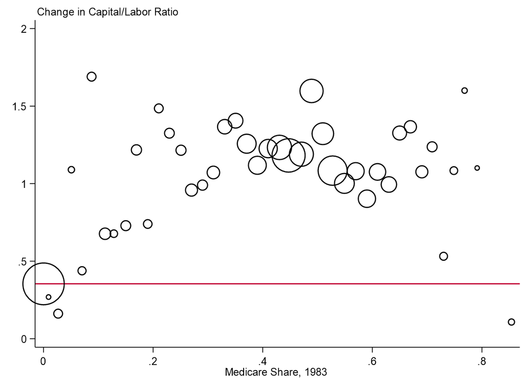

## ATE Plot

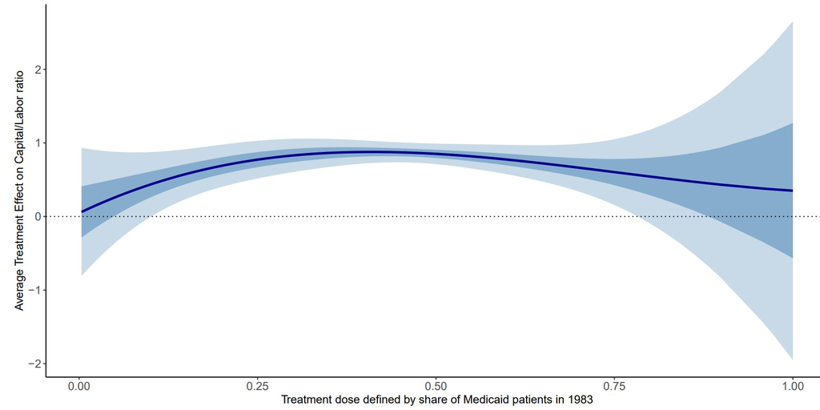

## ACR(T) Plot

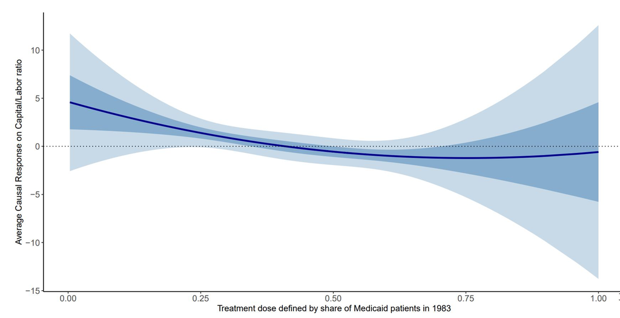

## Results

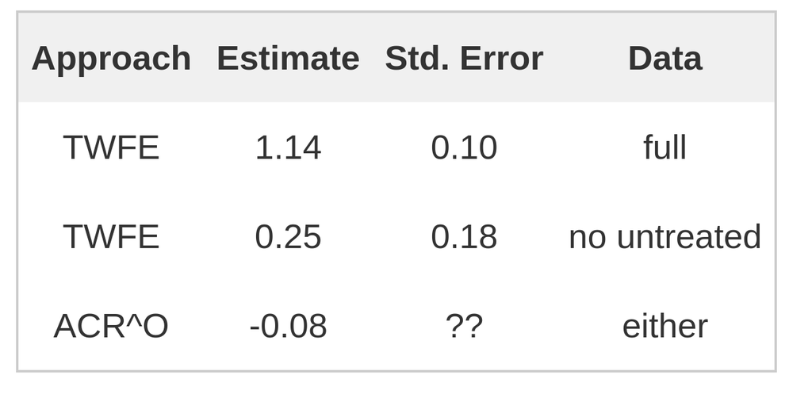

## Density weights vs. TWFE weights

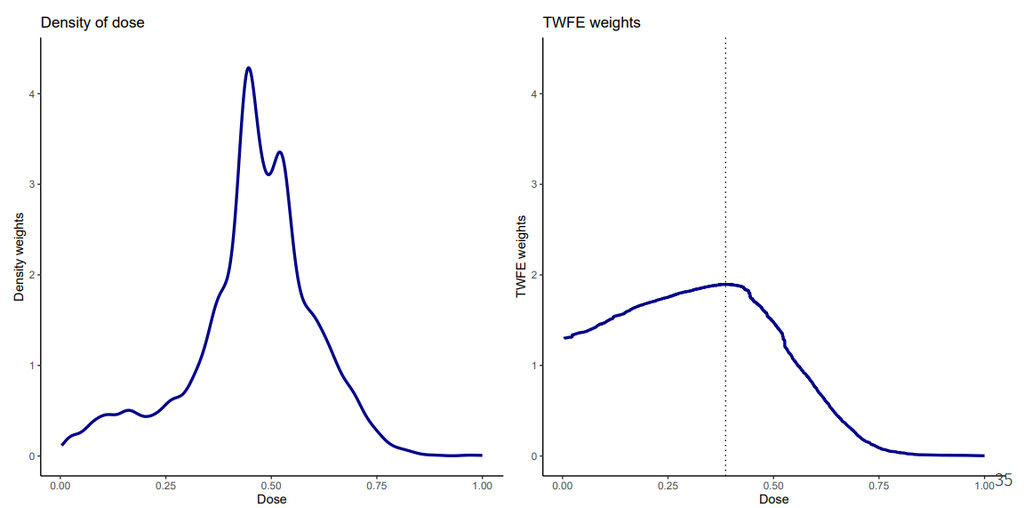

## TWFE Weights with and without Untreated Group

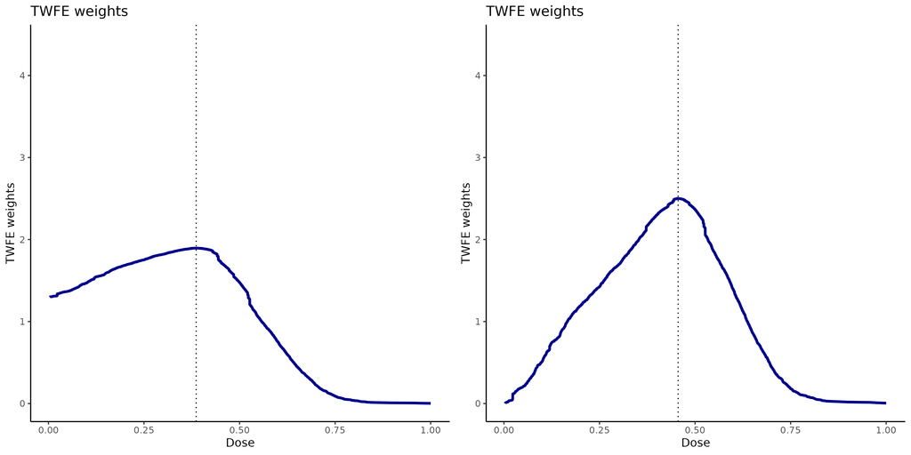

## Conclusion

- There are a number of challenges to implementing/interpreting DID with a continuous treatment
- The extension to multiple periods and variation in treatment timing is relatively straightforward (at least proceeds along the “expected” lines)
- But (in my view) the main new issue here is that justifying interpreting comparisons across different doses as causal effects requires stronger assumptions than most researchers probably think that they are making
- Link to paper: https://arxiv.org/abs/2107.02637
- Other Summaries: (i) [Five minute summary](https://bcallaway11.github.io/posts/five-minute-did-continuous-treatment) (ii) [Pedro’s Twitter](https://twitter.com/pedrohcgs/status/1415915759960690696)
- Comments welcome: brantly.callaway@uga.edu
- Code: in progress

# Appendix

## References

Borusyak, Kirill, Xavier Jaravel, and Jann Spiess. 2022. “Revisiting Event Study Designs: Robust and Efficient Estimation.”

Callaway, Brantly, and Pedro HC Sant’Anna. 2021. “Difference-in-Differences with Multiple Time Periods.” *Journal of Econometrics* 225 (2): 200–230.

de Chaisemartin, Clement, and Xavier D’Haultfœuille. 2020. “Two-Way Fixed Effects Estimators with Heterogeneous Treatment Effects.” *American Economic Review* 110 (9): 2964–96.

Dube, Arindrajit, Daniele Girardi, Òscar Jordà, and Alan M Taylor. 2023. “A Local Projections Approach to Difference-in-Differences Event Studies.”

Gardner, John. 2022. “Two-Stage Difference in Differences.”

Goodman-Bacon, Andrew. 2021. “Difference-in-Differences with Variation in Treatment Timing.” *Journal of Econometrics* 225 (2): 254–77.

Sun, Liyang, and Sarah Abraham. 2021. “Estimating Dynamic Treatment Effects in Event Studies with Heterogeneous Treatment Effects.” *Journal of Econometrics* 225 (2): 175–99.

Wooldridge, Jeff. 2021. “Two-Way Fixed Effects, the Two-Way Mundlak Regression, and Difference-in-Differences Estimators.”

## Can you relax strong parallel trends?

Some ideas:

- It could be reasonable to assume that you know the sign of the selection bias. This can lead to (possibly) informative bounds on differences/derivatives/etc. between $ATT(d|d)$ parameters
- Strong parallel trends may be more plausible after conditioning on some covariates.
  - For length of school closure, strong parallel trends probably more plausible conditional on being a rural county in the Southeast or conditional on being a college town in the Midwest.

Back

## Positive Side-Comments: No untreated units

It’s possible to do some versions of DID with a continuous treatment without having access to a fully untreated group.

- In this case, it is not possible to recover level effects like $ATT(d|d)$.
- However, notice that
  $$\begin{aligned}& \E[\Delta Y_t | D=d_h] - \E[\Delta Y_t | D=d_l] \\ &\hspace{50pt}= \Big(\E[\Delta Y_t | D=d_h] - \E[\Delta Y_t(0) | D=d_h]\Big) - \Big(\E[\Delta Y_t | D=d_l]-\E[\Delta Y_t(0) | D=d_l]\Big) \\ &\hspace{50pt}= ATT(d_h|d_h) - ATT(d_l|d_l)\end{aligned}$$
- In words: comparing path of outcomes for those that experienced dose $d_h$ to path of outcomes among those that experienced dose $d_l$ (and not relying on having an untreated group) delivers the difference between their $ATT$’s.
- Still face issues related to selection bias / strong parallel trends though

Back

## Positive Side-Comments: Alternative approaches

Strategies like binarizing the treatment can still work (though be careful!)

- If you classify units as being treated or untreated, you can recover the $ATT$ of being treated at all.
- On the other hand, if you classify units as being “high” treated, “low” treated, or untreated — our arguments imply that selection bias terms can come up when comparing effects for “high” to “low”

Back

## Negative Side-Comment: Pre-testing

That the expressions for $ATE(d)$ and $ATT(d|d)$ are exactly the same also means that we cannot use pre-treatment periods to try to distinguish between “standard” and “strong” parallel trends. In particular, the relevant information that we have for testing each one is the same

- In effect, the only testable implication of strong parallel trends in pre-treatment periods is standard parallel trends.

Back

# Issues with TWFE Regressions

## TWFE

The most common strategy in applied work is to estimate the two-way fixed effects (TWFE) regression:

$$Y_{it} = \theta_t + \eta_i + \beta^{twfe} D_{it} + v_{it}$$
In baseline case (two periods, no one treated in first period), this is just

$$\Delta Y_i = \beta_0 + \beta^{twfe} \cdot D_i + \Delta v_i$$

$\beta^{twfe}$ often (loosely) interpreted as some kind of average causal response (i.e., slope effect) parameter

## Interpreting $\beta^{twfe}$

In the paper, we show that

- Under Standard Parallel Trends:

  $$\beta^{tfwe} = \int_{\mathcal{D}_+} w_1(l) \left[ ACRT(l|l) + \frac{\partial ATT(l|h)}{\partial h} \Big|_{h=l} \right] \, dl$$
  - $w_1(l)$ are positive weights that integrate to 1
  - $ACRT(l|l)$ is average causal response conditional on $D=l$
  - $\frac{\partial ATT(l|h)}{\partial h} \Big|_{h=l}$ is a local selection bias term

## Interpreting $\beta^{twfe}$

In the paper, we show that

- Under Strong Parallel Trends:

  $$\beta^{tfwe} = \int_{\mathcal{D}_+} w_1(l) ACR(l) \, dl$$
  - $w_1(l)$ are same weights as before
  - $ACR(l)$ is average causal response to dose $l$ across entire population
  - there is no selection bias term

## What does this mean?

- Issue #1: Selection bias terms that show up under standard parallel trends

  $\implies$ to interpret as a weighted average of any kind of causal responses, need to invoke (likely substantially) stronger assumptions
- Issue #2: Weights
  - They are all positive
  - But this is a very minimal requirement for weights being “reasonable”
  - These weights have “strange” properties (i) affected by the size of the untreated group, (ii) that they are maximized at $d=\E[D]$.
  - [[Example 1 - Mixture of Normals Dose]] [[Example 2: Exponential Dose]]

## Application: Medicare Reform and Capital/Labor Ratios

We consider a simplified version of an application from Acemoglu and Finkelstein (2008) who study the effects of a 1983 Medicare reform that (roughly) eliminated hospital reimbursements for labor

- The continuous treatment is differential exposure to the policy based on the fraction of Medicare patients that the hospital had before the policy was implemented
- Idea: policy changes relative factor prices which suggests hospitals may adjust by changing their input mix.

**Results:**

- We provide conditions on production functions that rationalize invoking (or not invoking) strong parallel trends
- Our estimate of $ACR(d)$ (or $ACRT(d|d)$) is fairly heterogeneous across dose $\implies$ the results quite sensitive to the (implicit) TWFE weighting scheme [More Details…]

## Ex. Mixture of Normals Dose

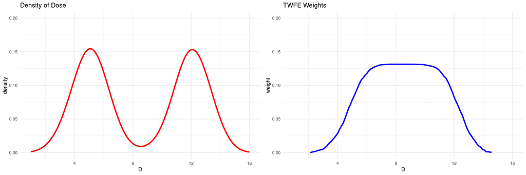

Back

## Ex. Exponential Dose

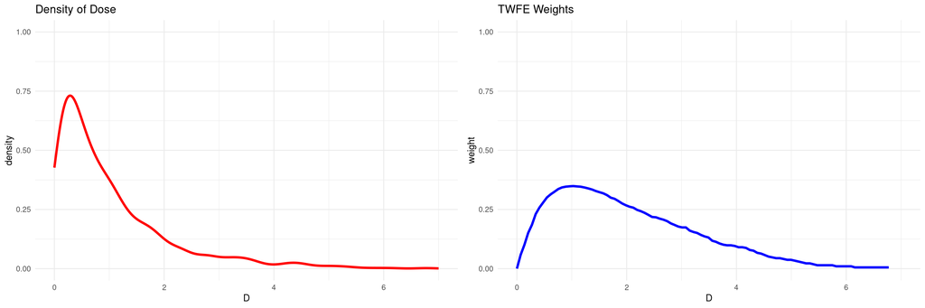

Back

# More General Case Multiple periods, variation in treatment timing

## Setup

- Staggered treatment adoption
  - If you are treated today, you will continue to be treated tomorrow
  - Note relatively straightforward to relax, just makes notation more complex
  - Can allow for treatment anticipation too, but ignoring for simplicity now
  - Once become treated, dose remains constant (could probably relax this too)

## Setup

- Additional Notation:
  - $G_i$ — a unit’s “group” (the time period when unit becomes treated)
  - Potential outcomes $Y_{it}(g,d)$ — the outcome unit $i$ would experience in time period $t$ if they became treated in period $g$ with dose $d$
  - $Y_{it}(0)$ is the potential outcome corresponding to not being treated in any period

## Parameters of Interest

Level Effects:

$$ATT(g,t,d|g,d) := \E[Y_t(g,d) - Y_t(0) | G=g, D=d] \ \ \ \textrm{and} \ \ \ ATE(g,t,d) := \E[Y_t(g,d) - Y_t(0) ]$$

Slope Effects:

$$ACRT(g,t,d|g,d) := \frac{\partial ATT(g,t,l|g,d)}{\partial l} \Big|_{l=d} \ \ \ \textrm{and} \ \ \ ACR(g,t,d) := \frac{\partial ATE(g,t,d)}{\partial d}$$

## Parameters of Interest

These essentially inherit all the same issues as in the two period case

- Under a multi-period version of “standard” parallel trends, comparisons of $ATT$ across different values of dose are hard to interpret
  - They contain selection bias terms
- Under a multi-period version of “strong” parallel trends, comparisons of $ATE$ across different values of dose straightforward to interpret
  - But this involves a much stronger assumption

Expressions in remainder of talk are under “strong” parallel trends

- Under “standard” parallel trends, add selection bias terms everywhere

## Parameters of Interest

Often, these are high-dimensional and it may be desirable to “aggregate” them

- Average by group (across post-treatment time periods) and then across groups

  $\rightarrow$ $ACR^{overall}(d)$ (overall average causal response for particular dose)
- Average $ACR^{overall}(d)$ across dose

  $\rightarrow$ $ACR^O$ (this is just one number) and is likely to be the parameter that one would be targeting in a TWFE regression
- Event study: average across groups who have been exposed to treatment for $e$ periods

  $\rightarrow$ For fixed $d$

  $\rightarrow$ Average across different values of $d$ $\implies$ typical looking ES plot

## TWFE in More General Case

## TWFE Regression

Consider the same TWFE regression as before

$$Y_{it} = \theta_t + \eta_i + \beta^{twfe} \cdot D_i \cdot Treat_{it} + v_{it}$$

## Running Example

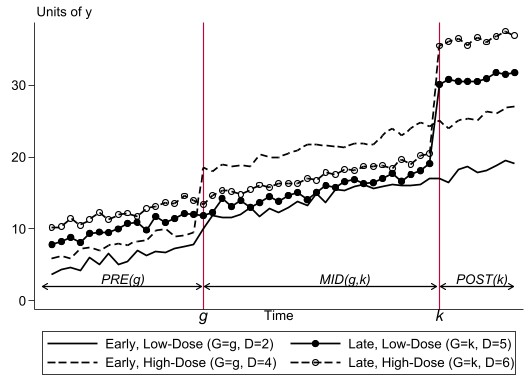

## How should $\beta^{twfe}$ be interpreted?

We show in the paper that $\beta^{twfe}$ is a weighted average of the following terms:

$$\delta^{WITHIN}(g) = \frac{\textrm{cov}(\bar{Y}^{POST}(g) - \bar{Y}^{PRE(g)}(g), D | G=g)}{\textrm{var(D|G=g)}}$$

- Comes from within-group variation in the amount of dose
- This term is essentially the same as in the baseline case and corresponds to a reasonable treatment effect parameter under strong parallel trends
- Like baseline case, (after some manipulations) this term corresponds to a “derivative”/“ACR”
- Does not show up in the binary treatment case because there is no variation in amount of treatment

## How should $\beta^{twfe}$ be interpreted?

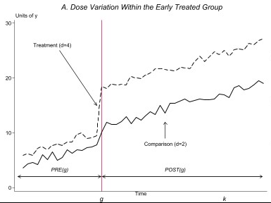

## How should $\beta^{twfe}$ be interpreted?

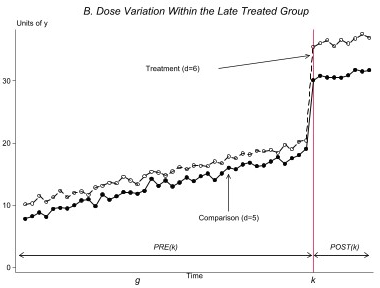

## $\beta^{twfe}$ weighted average, term 2 of 4

For $k > g$ (i.e., group $k$ becomes treated after group $g$),

$$\delta^{MID,PRE}(g,k) = \frac{\E\left[\big(\bar{Y}^{MID(g,k)} - \bar{Y}^{PRE(g)}\big) | G=g\right] - \E\left[\big(\bar{Y}^{MID(g,k)} - \bar{Y}^{PRE(g)}\big) | G=k \right]}{\E[D|G=g]}$$

- Comes from comparing path of outcomes for a group that becomes treated (group $g$) relative to a not-yet-treated group (group $k$)
- Corresponds to a reasonable treatment effect parameter under strong parallel trends
- Denominator (after some derivations) ends up giving this a “derivative”/“ACR” interpretation
- Similar terms show up in the case with a binary treatment

## $\beta^{twfe}$ weighted average, term 2 of 4

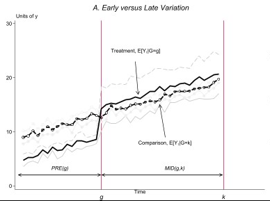

## $\beta^{twfe}$ weighted average, term 3 of 4

For $k > g$ (i.e., group $k$ becomes treated after group $g$),

$$\begin{aligned}
\delta^{POST,MID}(g,k) &= \frac{\E\left[\big(\bar{Y}^{POST(k)} - \bar{Y}^{MID(g,k)}\big) | G=k\right] - \E\left[\big(\bar{Y}^{POST(k)} - \bar{Y}^{MID(g,k)}\big) | D=0 \right]}{\E[D|G=k]} \\
&- \left(\frac{\E\left[\big(\bar{Y}^{POST(k)} - \bar{Y}^{PRE(k)}\big) | G=g\right] - \E\left[\big(\bar{Y}^{POST(k)} - \bar{Y}^{PRE(g)}\big) | D=0 \right]}{\E[D|G=k]} \right.\\
& \hspace{25pt} - \left.\frac{\E\left[\big(\bar{Y}^{MID(g,k)} - \bar{Y}^{PRE(k)}\big) | G=g\right] - \E\left[\big(\bar{Y}^{MID(g,k)} - \bar{Y}^{PRE(g)}\big) | D=0 \right]}{\E[D|G=k]} \right)
\end{aligned}$$

## $\beta^{twfe}$ weighted average, term 3 of 4

For $k > g$ (i.e., group $k$ becomes treated after group $g$),

$$\begin{aligned}
\delta^{POST,MID}(g,k) &= \frac{\E\left[\big(\bar{Y}^{POST(k)} - \bar{Y}^{MID(g,k)}\big) | G=k\right] - \E\left[\big(\bar{Y}^{POST(k)} - \bar{Y}^{MID(g,k)}\big) | D=0 \right]}{\E[D|G=k]} \\
&- \textrm{Treatment Effect Dynamics for Group g}
\end{aligned}$$
* Comes from comparing path of outcomes for a group that becomes treated (group $k$) to paths of outcomes of an already treated group (group $g$)

- In the presence of treatment effect dynamics (these are not ruled out by any parallel trends assumption), this term is problematic
- This is similar-in-spirit to the problematic terms for TWFE with a binary treatment

## $\beta^{twfe}$ weighted average, term 3 of 4

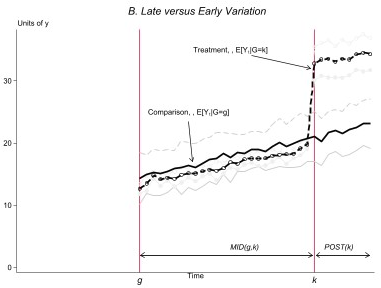

## $\beta^{twfe}$ weighted average, term 4 of 4

For $k > g$ (i.e., group $k$ becomes treated after group $g$),

$$\begin{aligned}
\delta^{POST,PRE}(g,k) = \frac{\E\left[\big(\bar{Y}^{POST(k)} - \bar{Y}^{PRE(g)}\big) | G=g\right] - \E\left[\big(\bar{Y}^{POST(k)} - \bar{Y}^{PRE(g)}\big) | G=k \right]}{\E[D|G=g] - \E[D|G=k]}
\end{aligned}$$
* Comes from comparing path of outcomes for groups $g$ and $k$ in their common post-treatment periods relative to their common pre-treatment periods

- In the presence of heterogeneous causal responses (causal response in same time period differs across groups), this term ends up being (partially) problematic too
- Only shows up when $\E[D|G=g] \neq \E[D|G=k]$
- No analogue in the binary treatment case

## $\beta^{twfe}$ weighted average, term 4 of 4

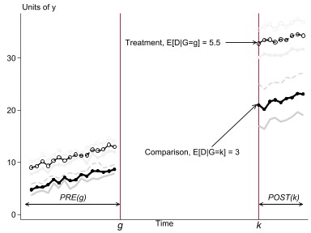

## Summary of TWFE Issues

- Issue #1: Selection bias terms that show up under standard parallel trends

  $\implies$ to interpret as a weighted average of any kind of causal responses, need to invoke (likely substantially) stronger assumptions
- Issue #2: Weights
  - Negative weights possible due to (i) treatment effect dynamics or (ii) heterogeneous causal responses across groups
  - Are (undesirably) driven by estimation method

Weights issues can be solved by carefully making desirable comparisons and user-chosen appropriate weights

Selection bias terms are more fundamental challenge